# Optimal Treatment Analysis

## Outcome Variable

**Outcome Variable:** haz

## Predictor Variables

**Intervention Variable:** impsan

**Adjustment Set:**

- arm
- sex
- W_mage
- meducyrs
- feducyrs
- hhwealth_quart
- hfoodsec
- W_mhtcm
- W_nrooms
- W_nchldlt5
- W_parity
- impfloor
- safeh20
- delta_W_mage
- delta_meducyrs
- delta_feducyrs
- delta_hhwealth_quart
- delta_hfoodsec
- delta_W_mhtcm
- delta_W_nrooms
- delta_W_nchldlt5
- delta_W_parity
- delta_impfloor
- delta_safeh20

## Stratifying Variables

The analysis was stratified on these variable(s):

- agecat
- studyid
- country

## Data Summary

| agecat | studyid | country | impsan | n_cell | n |
| --- | --- | --- | --- | --- | --- |
| Birth | ki0047075b-MAL-ED | BANGLADESH | 1 | 197 | 234 |
| Birth | ki0047075b-MAL-ED | BANGLADESH | 0 | 37 | 234 |
| Birth | ki0047075b-MAL-ED | BRAZIL | 1 | 170 | 174 |
| Birth | ki0047075b-MAL-ED | BRAZIL | 0 | 4 | 174 |
| Birth | ki0047075b-MAL-ED | INDIA | 1 | 92 | 190 |
| Birth | ki0047075b-MAL-ED | INDIA | 0 | 98 | 190 |
| Birth | ki0047075b-MAL-ED | NEPAL | 1 | 170 | 171 |
| Birth | ki0047075b-MAL-ED | NEPAL | 0 | 1 | 171 |
| Birth | ki0047075b-MAL-ED | PERU | 1 | 62 | 250 |
| Birth | ki0047075b-MAL-ED | PERU | 0 | 188 | 250 |
| Birth | ki0047075b-MAL-ED | SOUTH AFRICA | 1 | 2 | 213 |
| Birth | ki0047075b-MAL-ED | SOUTH AFRICA | 0 | 211 | 213 |
| Birth | ki0047075b-MAL-ED | TANZANIA, UNITED REPUBLIC OF | 1 | 0 | 113 |
| Birth | ki0047075b-MAL-ED | TANZANIA, UNITED REPUBLIC OF | 0 | 113 | 113 |
| Birth | ki1017093-NIH-Birth | BANGLADESH | 1 | 9 | 28 |
| Birth | ki1017093-NIH-Birth | BANGLADESH | 0 | 19 | 28 |
| Birth | ki1017093c-NIH-Crypto | BANGLADESH | 1 | 25 | 27 |
| Birth | ki1017093c-NIH-Crypto | BANGLADESH | 0 | 2 | 27 |
| Birth | ki1114097-CONTENT | PERU | 1 | 1 | 2 |
| Birth | ki1114097-CONTENT | PERU | 0 | 1 | 2 |
| Birth | ki1135781-COHORTS | GUATEMALA | 1 | 45 | 491 |
| Birth | ki1135781-COHORTS | GUATEMALA | 0 | 446 | 491 |
| Birth | ki1135781-COHORTS | INDIA | 1 | 1767 | 4776 |
| Birth | ki1135781-COHORTS | INDIA | 0 | 3009 | 4776 |
| Birth | ki1135781-COHORTS | PHILIPPINES | 1 | 178 | 1191 |
| Birth | ki1135781-COHORTS | PHILIPPINES | 0 | 1013 | 1191 |
| Birth | kiGH5241-JiVitA-3 | BANGLADESH | 1 | 13187 | 19592 |
| Birth | kiGH5241-JiVitA-3 | BANGLADESH | 0 | 6405 | 19592 |
| Birth | kiGH5241-JiVitA-4 | BANGLADESH | 1 | 606 | 822 |
| Birth | kiGH5241-JiVitA-4 | BANGLADESH | 0 | 216 | 822 |

[output cut: 68 more lines]

The following strata were considered:

- agecat: 24 months, studyid: ki0047075b-MAL-ED, country: BANGLADESH
- agecat: 24 months, studyid: ki0047075b-MAL-ED, country: BRAZIL
- agecat: 24 months, studyid: ki0047075b-MAL-ED, country: INDIA
- agecat: 24 months, studyid: ki0047075b-MAL-ED, country: NEPAL
- agecat: 24 months, studyid: ki0047075b-MAL-ED, country: PERU
- agecat: 24 months, studyid: ki0047075b-MAL-ED, country: SOUTH AFRICA
- agecat: 24 months, studyid: ki0047075b-MAL-ED, country: TANZANIA, UNITED REPUBLIC OF
- agecat: 24 months, studyid: ki1017093-NIH-Birth, country: BANGLADESH
- agecat: 24 months, studyid: ki1017093b-PROVIDE, country: BANGLADESH
- agecat: 24 months, studyid: ki1017093c-NIH-Crypto, country: BANGLADESH
- agecat: 24 months, studyid: ki1114097-CONTENT, country: PERU
- agecat: 24 months, studyid: ki1135781-COHORTS, country: GUATEMALA
- agecat: 24 months, studyid: ki1135781-COHORTS, country: INDIA
- agecat: 24 months, studyid: ki1135781-COHORTS, country: PHILIPPINES
- agecat: 24 months, studyid: ki1148112-LCNI-5, country: MALAWI
- agecat: 24 months, studyid: kiGH5241-JiVitA-3, country: BANGLADESH
- agecat: 24 months, studyid: kiGH5241-JiVitA-4, country: BANGLADESH
- agecat: 6 months, studyid: ki0047075b-MAL-ED, country: BANGLADESH
- agecat: 6 months, studyid: ki0047075b-MAL-ED, country: BRAZIL
- agecat: 6 months, studyid: ki0047075b-MAL-ED, country: INDIA
- agecat: 6 months, studyid: ki0047075b-MAL-ED, country: NEPAL
- agecat: 6 months, studyid: ki0047075b-MAL-ED, country: PERU
- agecat: 6 months, studyid: ki0047075b-MAL-ED, country: SOUTH AFRICA
- agecat: 6 months, studyid: ki0047075b-MAL-ED, country: TANZANIA, UNITED REPUBLIC OF
- agecat: 6 months, studyid: ki1017093-NIH-Birth, country: BANGLADESH
- agecat: 6 months, studyid: ki1017093b-PROVIDE, country: BANGLADESH
- agecat: 6 months, studyid: ki1017093c-NIH-Crypto, country: BANGLADESH
- agecat: 6 months, studyid: ki1114097-CONTENT, country: PERU
- agecat: 6 months, studyid: ki1135781-COHORTS, country: GUATEMALA
- agecat: 6 months, studyid: ki1135781-COHORTS, country: INDIA
- agecat: 6 months, studyid: ki1135781-COHORTS, country: PHILIPPINES
- agecat: 6 months, studyid: ki1148112-LCNI-5, country: MALAWI
- agecat: 6 months, studyid: kiGH5241-JiVitA-3, country: BANGLADESH
- agecat: 6 months, studyid: kiGH5241-JiVitA-4, country: BANGLADESH
- agecat: Birth, studyid: ki0047075b-MAL-ED, country: BANGLADESH
- agecat: Birth, studyid: ki0047075b-MAL-ED, country: BRAZIL
- agecat: Birth, studyid: ki0047075b-MAL-ED, country: INDIA
- agecat: Birth, studyid: ki0047075b-MAL-ED, country: NEPAL
- agecat: Birth, studyid: ki0047075b-MAL-ED, country: PERU
- agecat: Birth, studyid: ki0047075b-MAL-ED, country: SOUTH AFRICA
- agecat: Birth, studyid: ki0047075b-MAL-ED, country: TANZANIA, UNITED REPUBLIC OF
- agecat: Birth, studyid: ki1017093-NIH-Birth, country: BANGLADESH
- agecat: Birth, studyid: ki1017093c-NIH-Crypto, country: BANGLADESH
- agecat: Birth, studyid: ki1114097-CONTENT, country: PERU
- agecat: Birth, studyid: ki1135781-COHORTS, country: GUATEMALA
- agecat: Birth, studyid: ki1135781-COHORTS, country: INDIA
- agecat: Birth, studyid: ki1135781-COHORTS, country: PHILIPPINES
- agecat: Birth, studyid: kiGH5241-JiVitA-3, country: BANGLADESH
- agecat: Birth, studyid: kiGH5241-JiVitA-4, country: BANGLADESH

### Dropped Strata

- agecat: Birth, studyid: ki0047075b-MAL-ED, country: BRAZIL
- agecat: Birth, studyid: ki0047075b-MAL-ED, country: NEPAL
- agecat: Birth, studyid: ki0047075b-MAL-ED, country: SOUTH AFRICA
- agecat: Birth, studyid: ki0047075b-MAL-ED, country: TANZANIA, UNITED REPUBLIC OF
- agecat: Birth, studyid: ki1017093c-NIH-Crypto, country: BANGLADESH
- agecat: Birth, studyid: ki1114097-CONTENT, country: PERU
- agecat: 6 months, studyid: ki0047075b-MAL-ED, country: BRAZIL
- agecat: 6 months, studyid: ki0047075b-MAL-ED, country: NEPAL
- agecat: 6 months, studyid: ki0047075b-MAL-ED, country: SOUTH AFRICA
- agecat: 6 months, studyid: ki0047075b-MAL-ED, country: TANZANIA, UNITED REPUBLIC OF
- agecat: 6 months, studyid: ki1148112-LCNI-5, country: MALAWI
- agecat: 24 months, studyid: ki0047075b-MAL-ED, country: BRAZIL
- agecat: 24 months, studyid: ki0047075b-MAL-ED, country: NEPAL
- agecat: 24 months, studyid: ki0047075b-MAL-ED, country: SOUTH AFRICA
- agecat: 24 months, studyid: ki0047075b-MAL-ED, country: TANZANIA, UNITED REPUBLIC OF
- agecat: 24 months, studyid: ki1148112-LCNI-5, country: MALAWI

## Methods Detail

We’re interested in the causal parameters $E[Y_a]$ for all values of $a \in \mathcal{A}$. These parameters represent the mean outcome if, possibly contrary to fact, we intervened to set all units to have $A=a$. Under the randomization and positivity assumptions, these are identified by the statistical parameters $\psi_a=E_W[E_{Y|A,W}(Y|A=a,W)]$. In addition, we’re interested in the mean of $Y$, $E[Y]$ under no intervention (the observed mean). We will estimate these parameters by using SuperLearner to fit the relevant likelihood factors – $E_{Y|A,W}(Y|A=a,W)$ and $p(A=a|W)$, and then updating our likelihood fit using a joint TMLE.

For unadjusted analyses ($W=\{\}$), initial likelihoods were estimated using Lrnr_glm to estimate the simple $E(Y|A)$ and Lrnr_mean to estimate $p(A)$. For adjusted analyses, a small library containing Lrnr_glmnet, Lrnr_xgboost, and Lrnr_mean was used.

Having estimated these parameters, we will then use the delta method to estimate relative risks and attributable risks relative to a prespecified baseline level of $A$.

# Results Detail

## Results Plots

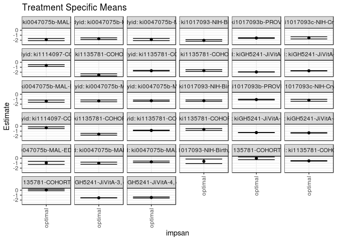

## Results Table

### Parameter: TSM

| agecat | studyid | country | intervention_level | baseline_level | estimate | ci_lower | ci_upper |
| --- | --- | --- | --- | --- | --- | --- | --- |
| Birth | ki0047075b-MAL-ED | BANGLADESH | optimal | observed | -0.9489028 | -1.2585507 | -0.6392549 |
| Birth | ki0047075b-MAL-ED | INDIA | optimal | observed | -1.0114584 | -1.2298387 | -0.7930782 |
| Birth | ki0047075b-MAL-ED | PERU | optimal | observed | -0.7338076 | -0.8837958 | -0.5838193 |
| Birth | ki1017093-NIH-Birth | BANGLADESH | optimal | observed | -0.6242438 | -1.0792191 | -0.1692685 |
| Birth | ki1135781-COHORTS | GUATEMALA | optimal | observed | -0.0162095 | -0.2902957 | 0.2578767 |
| Birth | ki1135781-COHORTS | INDIA | optimal | observed | -0.5405054 | -0.5967731 | -0.4842377 |
| Birth | ki1135781-COHORTS | PHILIPPINES | optimal | observed | 0.0440416 | -0.1058970 | 0.1939801 |
| Birth | kiGH5241-JiVitA-3 | BANGLADESH | optimal | observed | -1.5492164 | -1.5727118 | -1.5257209 |
| Birth | kiGH5241-JiVitA-4 | BANGLADESH | optimal | observed | -1.4807814 | -1.5972692 | -1.3642937 |
| 6 months | ki0047075b-MAL-ED | BANGLADESH | optimal | observed | -1.4005753 | -1.6192800 | -1.1818706 |
| 6 months | ki0047075b-MAL-ED | INDIA | optimal | observed | -1.3389810 | -1.5139272 | -1.1640347 |
| 6 months | ki0047075b-MAL-ED | PERU | optimal | observed | -1.3042875 | -1.4295655 | -1.1790096 |
| 6 months | ki1017093-NIH-Birth | BANGLADESH | optimal | observed | -1.2971973 | -1.4389966 | -1.1553980 |
| 6 months | ki1017093b-PROVIDE | BANGLADESH | optimal | observed | -1.0810150 | -1.1589933 | -1.0030368 |
| 6 months | ki1017093c-NIH-Crypto | BANGLADESH | optimal | observed | -1.2156891 | -1.4150060 | -1.0163722 |
| 6 months | ki1114097-CONTENT | PERU | optimal | observed | -0.2973040 | -0.4770083 | -0.1175997 |
| 6 months | ki1135781-COHORTS | GUATEMALA | optimal | observed | -1.6218824 | -1.8071819 | -1.4365829 |
| 6 months | ki1135781-COHORTS | INDIA | optimal | observed | -0.8518689 | -0.9059200 | -0.7978177 |
| 6 months | ki1135781-COHORTS | PHILIPPINES | optimal | observed | -0.6556594 | -0.8339688 | -0.4773500 |
| 6 months | kiGH5241-JiVitA-3 | BANGLADESH | optimal | observed | -1.2829810 | -1.3086126 | -1.2573494 |
| 6 months | kiGH5241-JiVitA-4 | BANGLADESH | optimal | observed | -1.3404114 | -1.3894586 | -1.2913643 |
| 24 months | ki0047075b-MAL-ED | BANGLADESH | optimal | observed | -1.8722823 | -2.0903677 | -1.6541970 |
| 24 months | ki0047075b-MAL-ED | INDIA | optimal | observed | -1.7002691 | -1.8695733 | -1.5309649 |
| 24 months | ki0047075b-MAL-ED | PERU | optimal | observed | -1.8644461 | -2.0828098 | -1.6460825 |
| 24 months | ki1017093-NIH-Birth | BANGLADESH | optimal | observed | -2.0421575 | -2.2099449 | -1.8743702 |
| 24 months | ki1017093b-PROVIDE | BANGLADESH | optimal | observed | -1.5635297 | -1.6477975 | -1.4792619 |
| 24 months | ki1017093c-NIH-Crypto | BANGLADESH | optimal | observed | -1.5310190 | -1.7515450 | -1.3104930 |
| 24 months | ki1114097-CONTENT | PERU | optimal | observed | -0.6542191 | -0.8334293 | -0.4750089 |
| 24 months | ki1135781-COHORTS | GUATEMALA | optimal | observed | -2.5501990 | -2.7607138 | -2.3396843 |
| 24 months | ki1135781-COHORTS | INDIA | optimal | observed | -1.7047283 | -1.7679249 | -1.6415317 |
| 24 months | ki1135781-COHORTS | PHILIPPINES | optimal | observed | -1.6788614 | -1.8559500 | -1.5017729 |
| 24 months | kiGH5241-JiVitA-3 | BANGLADESH | optimal | observed | -1.9611848 | -1.9931358 | -1.9292338 |
| 24 months | kiGH5241-JiVitA-4 | BANGLADESH | optimal | observed | -1.7266804 | -1.7676843 | -1.6856764 |

### Parameter: E(Y)

| agecat | studyid | country | intervention_level | baseline_level | estimate | ci_lower | ci_upper |
| --- | --- | --- | --- | --- | --- | --- | --- |
| Birth | ki0047075b-MAL-ED | BANGLADESH | observed | observed | -1.0229487 | -1.1509575 | -0.8949400 |
| Birth | ki0047075b-MAL-ED | INDIA | observed | observed | -0.9912632 | -1.1342711 | -0.8482552 |
| Birth | ki0047075b-MAL-ED | PERU | observed | observed | -0.9430000 | -1.0581275 | -0.8278725 |
| Birth | ki1017093-NIH-Birth | BANGLADESH | observed | observed | -0.5292857 | -0.8821252 | -0.1764462 |
| Birth | ki1135781-COHORTS | GUATEMALA | observed | observed | -0.0275356 | -0.1359303 | 0.0808590 |
| Birth | ki1135781-COHORTS | INDIA | observed | observed | -0.6777115 | -0.7106054 | -0.6448175 |
| Birth | ki1135781-COHORTS | PHILIPPINES | observed | observed | -0.3137364 | -0.3764483 | -0.2510244 |
| Birth | kiGH5241-JiVitA-3 | BANGLADESH | observed | observed | -1.5751797 | -1.5949356 | -1.5554237 |
| Birth | kiGH5241-JiVitA-4 | BANGLADESH | observed | observed | -1.4976642 | -1.5817349 | -1.4135935 |
| 6 months | ki0047075b-MAL-ED | BANGLADESH | observed | observed | -1.2033681 | -1.3212429 | -1.0854932 |
| 6 months | ki0047075b-MAL-ED | INDIA | observed | observed | -1.2137196 | -1.3330761 | -1.0943631 |
| 6 months | ki0047075b-MAL-ED | PERU | observed | observed | -1.3210330 | -1.4311040 | -1.2109619 |
| 6 months | ki1017093-NIH-Birth | BANGLADESH | observed | observed | -1.4073821 | -1.4960598 | -1.3187043 |
| 6 months | ki1017093b-PROVIDE | BANGLADESH | observed | observed | -1.0925674 | -1.1686395 | -1.0164954 |
| 6 months | ki1017093c-NIH-Crypto | BANGLADESH | observed | observed | -1.2031037 | -1.2749632 | -1.1312442 |
| 6 months | ki1114097-CONTENT | PERU | observed | observed | -0.3139217 | -0.4868486 | -0.1409948 |
| 6 months | ki1135781-COHORTS | GUATEMALA | observed | observed | -1.8789210 | -1.9609921 | -1.7968498 |
| 6 months | ki1135781-COHORTS | INDIA | observed | observed | -1.0414424 | -1.0741113 | -1.0087734 |
| 6 months | ki1135781-COHORTS | PHILIPPINES | observed | observed | -1.1942936 | -1.2608624 | -1.1277248 |
| 6 months | kiGH5241-JiVitA-3 | BANGLADESH | observed | observed | -1.3134804 | -1.3366079 | -1.2903528 |
| 6 months | kiGH5241-JiVitA-4 | BANGLADESH | observed | observed | -1.3440477 | -1.3813060 | -1.3067894 |
| 24 months | ki0047075b-MAL-ED | BANGLADESH | observed | observed | -1.9431132 | -2.0691678 | -1.8170586 |
| 24 months | ki0047075b-MAL-ED | INDIA | observed | observed | -1.8372222 | -1.9638017 | -1.7106427 |
| 24 months | ki0047075b-MAL-ED | PERU | observed | observed | -1.7514286 | -1.8732727 | -1.6295845 |
| 24 months | ki1017093-NIH-Birth | BANGLADESH | observed | observed | -2.1807945 | -2.2835902 | -2.0779987 |
| 24 months | ki1017093b-PROVIDE | BANGLADESH | observed | observed | -1.5853993 | -1.6687810 | -1.5020176 |
| 24 months | ki1017093c-NIH-Crypto | BANGLADESH | observed | observed | -1.4297217 | -1.5139732 | -1.3454701 |
| 24 months | ki1114097-CONTENT | PERU | observed | observed | -0.6962195 | -0.8674103 | -0.5250287 |
| 24 months | ki1135781-COHORTS | GUATEMALA | observed | observed | -2.8674777 | -2.9383136 | -2.7966417 |
| 24 months | ki1135781-COHORTS | INDIA | observed | observed | -2.0003783 | -2.0396528 | -1.9611037 |
| 24 months | ki1135781-COHORTS | PHILIPPINES | observed | observed | -2.5681010 | -2.6370882 | -2.4991138 |
| 24 months | kiGH5241-JiVitA-3 | BANGLADESH | observed | observed | -2.0126943 | -2.0403978 | -1.9849907 |
| 24 months | kiGH5241-JiVitA-4 | BANGLADESH | observed | observed | -1.7578934 | -1.7933205 | -1.7224663 |

### Parameter: PAR

| agecat | studyid | country | intervention_level | baseline_level | estimate | ci_lower | ci_upper |
| --- | --- | --- | --- | --- | --- | --- | --- |
| Birth | ki0047075b-MAL-ED | BANGLADESH | optimal | observed | -0.0740459 | -0.3617612 | 0.2136693 |
| Birth | ki0047075b-MAL-ED | INDIA | optimal | observed | 0.0201953 | -0.1250372 | 0.1654277 |
| Birth | ki0047075b-MAL-ED | PERU | optimal | observed | -0.2091924 | -0.3481012 | -0.0702837 |
| Birth | ki1017093-NIH-Birth | BANGLADESH | optimal | observed | 0.0949581 | -0.3644289 | 0.5543451 |
| Birth | ki1135781-COHORTS | GUATEMALA | optimal | observed | -0.0113261 | -0.2663037 | 0.2436514 |
| Birth | ki1135781-COHORTS | INDIA | optimal | observed | -0.1372061 | -0.1832719 | -0.0911403 |
| Birth | ki1135781-COHORTS | PHILIPPINES | optimal | observed | -0.3577779 | -0.5006012 | -0.2149546 |
| Birth | kiGH5241-JiVitA-3 | BANGLADESH | optimal | observed | -0.0259633 | -0.0383259 | -0.0136007 |
| Birth | kiGH5241-JiVitA-4 | BANGLADESH | optimal | observed | -0.0168828 | -0.0979116 | 0.0641460 |
| 6 months | ki0047075b-MAL-ED | BANGLADESH | optimal | observed | 0.1972072 | -0.0009122 | 0.3953267 |
| 6 months | ki0047075b-MAL-ED | INDIA | optimal | observed | 0.1252614 | 0.0031902 | 0.2473326 |
| 6 months | ki0047075b-MAL-ED | PERU | optimal | observed | -0.0167454 | -0.0829093 | 0.0494185 |
| 6 months | ki1017093-NIH-Birth | BANGLADESH | optimal | observed | -0.1101848 | -0.2211107 | 0.0007412 |
| 6 months | ki1017093b-PROVIDE | BANGLADESH | optimal | observed | -0.0115524 | -0.0275396 | 0.0044348 |
| 6 months | ki1017093c-NIH-Crypto | BANGLADESH | optimal | observed | 0.0125854 | -0.1713029 | 0.1964737 |
| 6 months | ki1114097-CONTENT | PERU | optimal | observed | -0.0166177 | -0.0593153 | 0.0260799 |
| 6 months | ki1135781-COHORTS | GUATEMALA | optimal | observed | -0.2570386 | -0.4355719 | -0.0785053 |
| 6 months | ki1135781-COHORTS | INDIA | optimal | observed | -0.1895735 | -0.2342628 | -0.1448841 |
| 6 months | ki1135781-COHORTS | PHILIPPINES | optimal | observed | -0.5386343 | -0.7079532 | -0.3693153 |
| 6 months | kiGH5241-JiVitA-3 | BANGLADESH | optimal | observed | -0.0304994 | -0.0413626 | -0.0196362 |
| 6 months | kiGH5241-JiVitA-4 | BANGLADESH | optimal | observed | -0.0036362 | -0.0349668 | 0.0276944 |
| 24 months | ki0047075b-MAL-ED | BANGLADESH | optimal | observed | -0.0708309 | -0.2661614 | 0.1244997 |
| 24 months | ki0047075b-MAL-ED | INDIA | optimal | observed | -0.1369531 | -0.2711826 | -0.0027237 |
| 24 months | ki0047075b-MAL-ED | PERU | optimal | observed | 0.1130176 | -0.0765674 | 0.3026025 |
| 24 months | ki1017093-NIH-Birth | BANGLADESH | optimal | observed | -0.1386369 | -0.2626688 | -0.0146051 |
| 24 months | ki1017093b-PROVIDE | BANGLADESH | optimal | observed | -0.0218696 | -0.0430496 | -0.0006896 |
| 24 months | ki1017093c-NIH-Crypto | BANGLADESH | optimal | observed | 0.1012973 | -0.1028287 | 0.3054233 |
| 24 months | ki1114097-CONTENT | PERU | optimal | observed | -0.0420004 | -0.0886643 | 0.0046635 |
| 24 months | ki1135781-COHORTS | GUATEMALA | optimal | observed | -0.3172787 | -0.5236374 | -0.1109199 |
| 24 months | ki1135781-COHORTS | INDIA | optimal | observed | -0.2956500 | -0.3480284 | -0.2432715 |
| 24 months | ki1135781-COHORTS | PHILIPPINES | optimal | observed | -0.8892396 | -1.0606819 | -0.7177973 |
| 24 months | kiGH5241-JiVitA-3 | BANGLADESH | optimal | observed | -0.0515095 | -0.0673224 | -0.0356966 |
| 24 months | kiGH5241-JiVitA-4 | BANGLADESH | optimal | observed | -0.0312130 | -0.0490392 | -0.0133869 |